# hw-02

Your Name (S2912479)

2026-10-30

```r
strava_runs <- read_csv("data/strava_runs.csv")
data_5k_10k <- strava_runs %>%
  mutate(
    event = case_when(
      distance..m. > 4998 & distance..m. < 5015  ~ "5k",
      distance..m. > 9998 & distance..m. < 10015 ~ "10k",
      TRUE ~ NA_character_
    )
  ) %>%
  filter(!is.na(event))
```

## Exercise 1

When you fill the missing part, remove the # symbol before running the code chunk and eval=FALSE

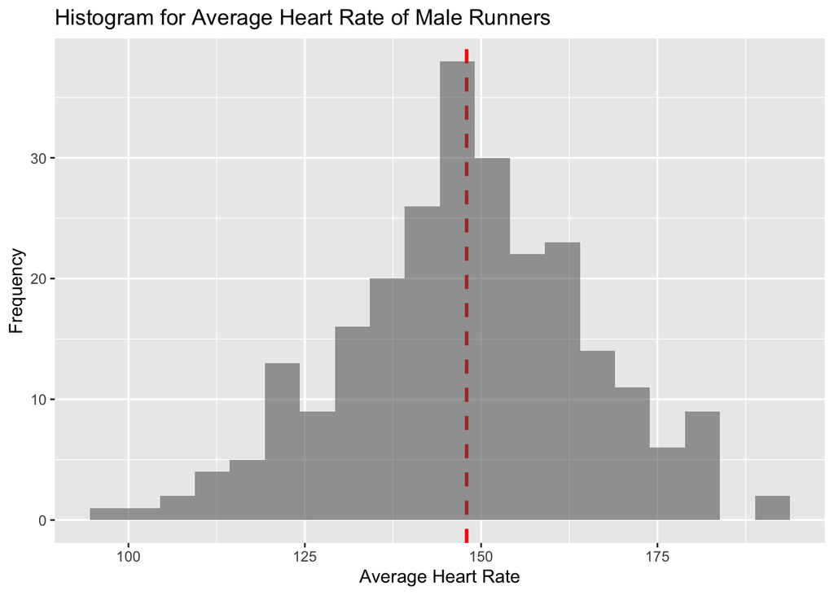

```r
data_5k_10k %>%
  filter(gender == "M") %>%
  filter(!is.na(average.heart.rate..bpm.)) %>%
  ggplot(aes(x = average.heart.rate..bpm., alpha =.5)) +
  geom_vline(aes(xintercept = mean(average.heart.rate..bpm.)),
             color = "red", linetype = "dashed", linewidth = 1) +
  geom_histogram(bins = 20) +
  labs( title = "Histogram for Average Heart Rate of Male Runners",
        y = "Frequency", x = "Average Heart Rate") +
  theme(legend.position = "none")
```

Mean Heart Rate = 147.9

Most runners average heart rate between 130 and 170 beats per minute, implies large range of runners of different abilities participating in data submission. Either means some runers have either better cardio vascular system and do not need to go as hard (or just generally taking it easier) and some runners going harder pushing upper cardio vascular zones.

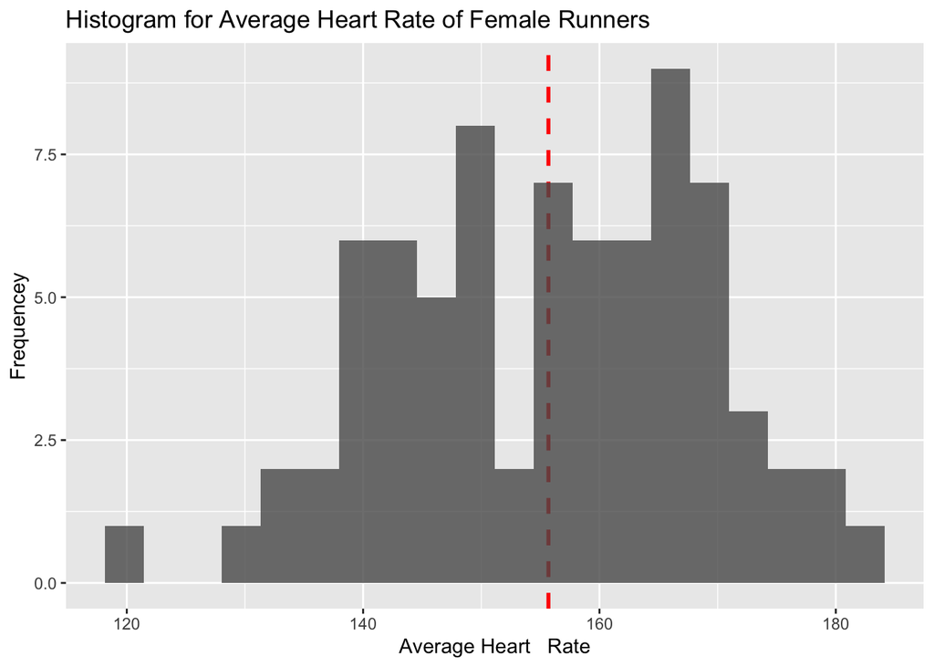

```r
data_5k_10k %>%
  filter(gender == "F") |>
  filter(!is.na(average.heart.rate..bpm.)) %>%
  ggplot(aes(x = average.heart.rate..bpm., alpha = 0.5)) +
  geom_vline(aes(xintercept = mean(average.heart.rate..bpm.)),
             color = "red", linetype = "dashed", linewidth = 1) +
  geom_histogram(bins = 20) +
  labs(title = "Histogram for Average Heart Rate of Female Runners", y = "Frequencey", x = "Average Heart   Rate")+
  geom_histogram(bins = 20 ) +
  theme(legend.position = "none")
```

Mean Heart Rate = 155.7

Mean heart rate of female runner is a lot higher than mean for set, implies that female runners may find the run harder than male counter parts.

## Exercise 2

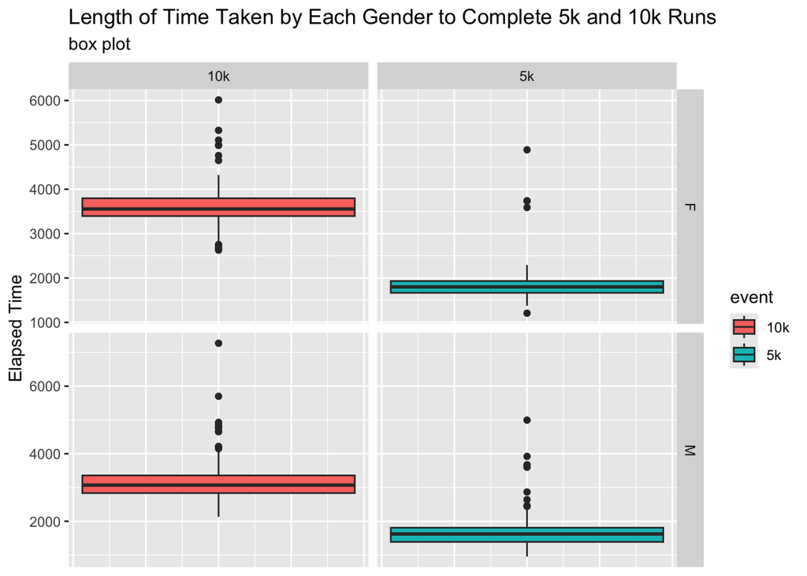

```r
filter(data_5k_10k, !is.na(gender)) |>
  ggplot() +
    aes(y = elapsed.time..s., fill = event) +
    geom_boxplot() +
    facet_grid( gender ~ event, scales = "free" ) +
    labs( y = "Elapsed Time",
           title = "Length of Time Taken by Each Gender to Complete 5k and 10k Runs", subtitle = "box plot") +
    theme(axis.ticks.x=element_blank(), axis.text.x=element_blank())
```

The Inter quartile range is very small compared to total range of data. Most the serious runners lie in a small range of times whilst a few, perhaps beginner, runners take significantly longer to run the same distance - or, the times were recorded on routes which had significant elevation gain, making the run take longer as it is harder.

## Exercise 3

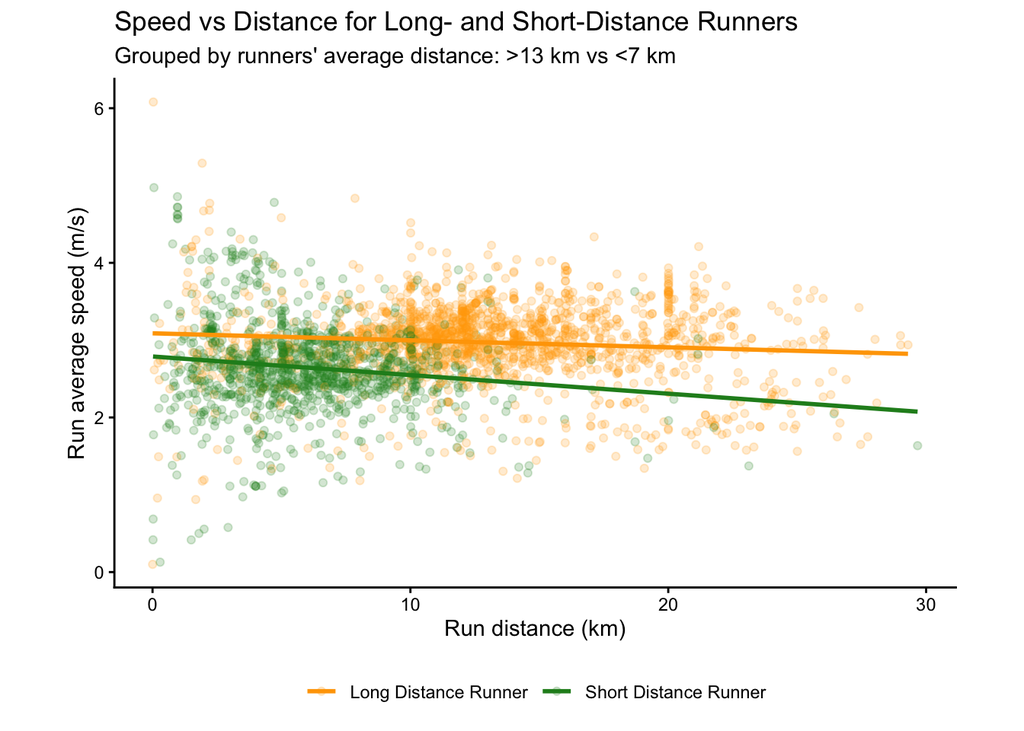

```r
long_vs_short <- strava_runs |>
  filter(!is.na(distance..m.)) |>
  group_by(athlete) |>
    mutate(
      l_or_s = case_when(
        mean(distance..m., na.rm = TRUE) < 7000 ~ "Short Distance Runner",
        mean(distance..m., na.rm = TRUE) > 13000 ~ "Long Distance Runner",
        TRUE ~ "Medium Distance Runner" ),
      distance..km. = distance..m./1000) |>
  filter(l_or_s != "Medium Distance Runner") |>
  ungroup(athlete) |>
  mutate(average.speed = distance..m./elapsed.time..s.)

long_vs_short |>
  ggplot(aes(x = distance..km., y = average.speed, colour = l_or_s)) +
  geom_point(alpha = 0.2) +
  geom_smooth(method = "lm", linewidth = 1, se = F ) +
  theme_classic() +
  labs(title = "Speed vs Distance for Long- and Short-Distance Runners",
       subtitle = "Grouped by runners' average distance: >13 km vs <7 km",
       x = "Run distance (km)",
       y = "Run average speed (m/s)") +
  coord_fixed( ratio = 3) +
  theme(legend.position = "bottom", legend.title = element_blank()) +
  scale_colour_manual(values = c("Long Distance Runner" = "orange",
                                 "Short Distance Runner" = "forestgreen"))
```

On average, according to the regression line, the long distance runners run faster for all length runs. However, the gap gets larger as the runs get longer and longer, this could be because all proffesional trained runners will naturally run faster no matter the length, but mostly train long runs to improve cardiovascular generally.

## Exercise 4

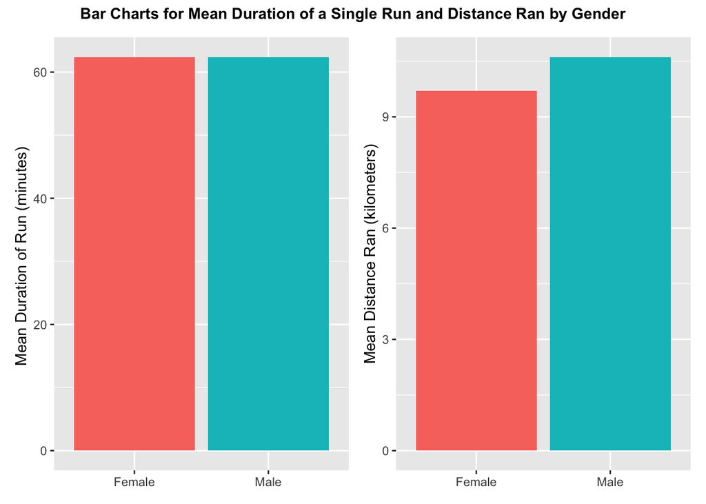

```r
mean_stats_by_gender <- strava_runs |>
  filter(!is.na(gender)) |>
  mutate(gender = recode(gender, "M" = 'Male', "F" = 'Female')) |>
  group_by(gender) |>
  summarise(mean.distance..km. = mean(distance..m.)/1000,
            mean.elapsed.time..mins. = mean(elapsed.time..s.)/60) |>
 ungroup()

time_plot <- ggplot(mean_stats_by_gender, mapping = aes( x = gender,
  y = mean.elapsed.time..mins., fill = gender)) +
  geom_col( ) +
  labs( y = "Mean Duration of Run (minutes) ") +
  theme(legend.position = "none", axis.title.x=element_blank())

distance_plot <- ggplot(mean_stats_by_gender, mapping = aes( x = gender,
  y = mean.distance..km., fill = gender)) +
  geom_col() +
  labs( y = "Mean Distance Ran (kilometers)") +
  theme(legend.position = "none", axis.title.x=element_blank())

time_plot + distance_plot +
  plot_annotation(
    title = "Bar Charts for Mean Duration of a Single Run and Distance Ran by Gender",
    theme = theme(
      plot.title = element_text(size = 11, face = "bold", hjust = 0.5)
   ))
```

The average duration of a run for both men and women is approximatley the same; however, for that same average run length, men typically run further. This could be due to their greater anareobic capacity and muscle density allowing them to travel further in the same length of time.